# Vaibhav_AppliedStats_Assignment

Applied Stats *Project* Vaibhav Bhatnagar

Q1. Import the necessary libraries

```python
import numpy as np
import pandas as pd
import matplotlib.pyplot as plt
from statsmodels.graphics.mosaicplot import mosaic
import seaborn as sns
sns.set(color_codes=True)
import statsmodels.api         as     sm
from   statsmodels.formula.api import ols
import scipy.stats as stats
import scipy
```

Q2. Read the data as a data frame

```python
Dataframe = pd.read_csv('insurance.csv') # Import the dataset named 'insurance.csv'
```

Q3a. Shape of the data

```python
Dataframe.shape #This is to get the shape of data. Shape of data referring to the #of rows and #of Columns present in dataset
```

```
(1338, 7)
```

This Dataset have 1338 rows or observations and 7 columns or attributes

Q3b. Data type of each attribute

```python
Dataframe.info() #This is to get the info of each attribute in dataset
```

```
<class 'pandas.core.frame.DataFrame'>
RangeIndex: 1338 entries, 0 to 1337
Data columns (total 7 columns):
age         1338 non-null int64
sex         1338 non-null object
bmi         1338 non-null float64
children    1338 non-null int64
smoker      1338 non-null object
region      1338 non-null object
charges     1338 non-null float64
dtypes: float64(2), int64(2), object(3)
memory usage: 73.3+ KB
```

From the info function result on Dataframe set we can infer that 3 object (Char/string) datatype attributes (sex, smoker, region) 2 float64 (decimal) datatype attributes (charges, bmi) 2 int64 (integer) datatype attributes (children, age)

Second observation from above result set is that there are no missing values in the data set.

Q3c. Checking the presence of missing values

```python
Dataframe[pd.isnull(Dataframe).any(axis=1)] # This is to check explicitly whether dataframe has any Null values.
#The result will only select the records if any attribute has Null values.
```

|  | age | sex | bmi | children | smoker | region | charges |
| --- | --- | --- | --- | --- | --- | --- | --- |

From the above two results we can confidently say that there are no null values. Firstly from info command we can see that all the attributes have non-null values Secondly using the isnull function with any axis check returning no rows gives the confidence to say dataset doesn't have any Null Values

Q3d. 5 point summary of numerical attributes

```python
Dataframe.describe()
```

|  | age | bmi | children | charges |
| --- | --- | --- | --- | --- |
| count | 1338.000000 | 1338.000000 | 1338.000000 | 1338.000000 |
| mean | 39.207025 | 30.663397 | 1.094918 | 13270.422265 |
| std | 14.049960 | 6.098187 | 1.205493 | 12110.011237 |
| min | 18.000000 | 15.960000 | 0.000000 | 1121.873900 |
| 25% | 27.000000 | 26.296250 | 0.000000 | 4740.287150 |
| 50% | 39.000000 | 30.400000 | 1.000000 | 9382.033000 |
| 75% | 51.000000 | 34.693750 | 2.000000 | 16639.912515 |
| max | 64.000000 | 53.130000 | 5.000000 | 63770.428010 |

Q3e. Distribution of ‘bmi’, ‘age’ and ‘charges’ columns.

```python
Dataframe.quantile(0.75) - Dataframe.quantile(0.25)
#This helps in analyzing the interquartile range for the numeric datatype variable
```

```
age            24.000000
bmi             8.397500
children        2.000000
charges     11899.625365
dtype: float64
```

```python
Dataframe.max(numeric_only=True) - Dataframe.min(numeric_only=True)
#This helps in understanding the range of values for each numeric datatypes
```

```
age            46.00000
bmi            37.17000
children        5.00000
charges     62648.55411
dtype: float64
```

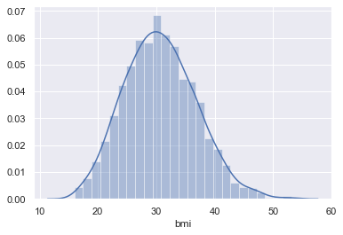

```python
sns.distplot(Dataframe['bmi']) # This gives a visual description of the distribution of values of the variable
```

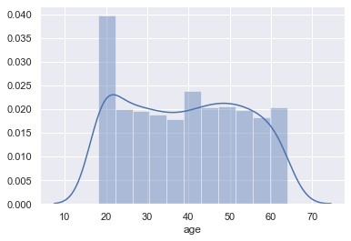

```python
sns.distplot(Dataframe['age']) # This gives a visual description of the distribution of values of the variable
```

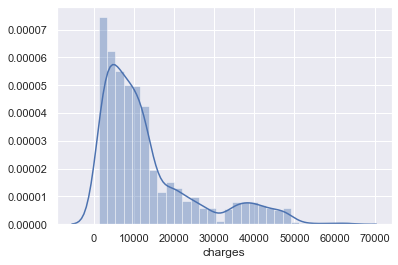

```python
sns.distplot(Dataframe['charges']) # This gives a visual description of the distribution of values of the variable
```

Q3f. Measure of skewness of ‘bmi’, ‘age’ and ‘charges’ columns

```python
Dataframe.skew()#This is to get the skewness of the data for the numeric columns
```

```
age         0.055673
bmi         0.284047
children    0.938380
charges     1.515880
dtype: float64
```

Q3g. Checking the presence of outliers in ‘bmi’, ‘age’ and ‘charges columns

To determine the Outliers. We need to see what values are lying beyong the IQR which is being defiened earlier for all the three numeric variables. To represent this graphphically we usually use box plot. Here I'm going to plot all the three variables seperately as they will have different scales. In case of plotting on same grapgh the results might not be deduced easily due to scaling.

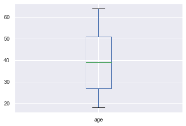

```python
Dataframe.boxplot(column=["age"])# this doesn't show any outliers
```

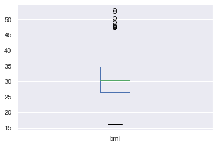

```python
Dataframe.boxplot(column=["bmi"])# this shows we have outliers on one side
```

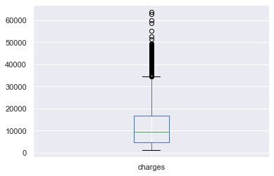

```python
Dataframe.boxplot(column=["charges"])# this shows we have outliers on one side
```

```python
Q1=Dataframe.quantile(0.25)
Q3=Dataframe.quantile(0.75)
IQR=Q3-Q1
(Dataframe < (Q1 - 1.5 * IQR)) |(Dataframe > (Q3 + 1.5 * IQR))
#This defines which records are the outliers.
```

|  | age | bmi | charges | children | region | sex | smoker |
| --- | --- | --- | --- | --- | --- | --- | --- |
| 0 | False | False | False | False | False | False | False |
| 1 | False | False | False | False | False | False | False |
| 2 | False | False | False | False | False | False | False |
| 3 | False | False | False | False | False | False | False |
| 4 | False | False | False | False | False | False | False |
| ... | ... | ... | ... | ... | ... | ... | ... |
| 1333 | False | False | False | False | False | False | False |
| 1334 | False | False | False | False | False | False | False |
| 1335 | False | False | False | False | False | False | False |
| 1336 | False | False | False | False | False | False | False |
| 1337 | False | False | False | False | False | False | False |

1338 rows × 7 columns

Q3h. Distribution of categorical columns (include children)

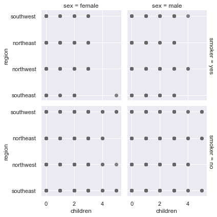

```python
g = sns.FacetGrid(Dataframe, col ='sex', row='smoker', margin_titles=True)
g.map(sns.regplot,'children','region',color=".4",fit_reg=False, x_jitter=0)
# This gives the distribution of the categorical variables in the visual form
```

Q3i. Pair plot that includes all the columns of the data frame

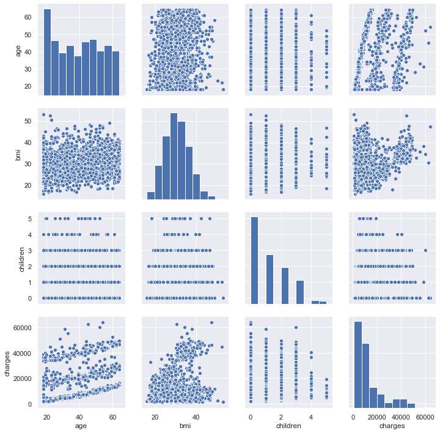

```python
sns.pairplot(Dataframe)
# this is to do the pair plot of all the numeric variable. It helps to understand the relation among all the variables.
```

Q4a. Do charges of people who smoke differ significantly from the people who don't?

```python
Dataframe_Smk = Dataframe[Dataframe["smoker"]=="yes"]
Dataframe_Smk['charges'].mean()
```

```
32050.23183153285
```

```python
Dataframe_NSmk = Dataframe[Dataframe["smoker"]=="no"]
Dataframe_NSmk['charges'].mean()
```

```
8434.268297856199
```

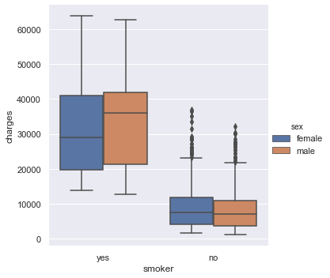

```python
sns.catplot(x="smoker",y="charges",hue="sex",data=Dataframe,kind="box")
```

To analyse the charges levied based on smoker or not. We have done the subsetting of data based on somker attribute which is categorical. Further to support the argument statistically we calculated the mean of the subsets which clearly shows the difference between the two datasets and can be inferred that Somker have to pay higher charges as compared to nonsmokers.

For supporting our argument we also did the box plotting and further seggregated the data based on sex sill we see the 5 point description for non smoker dataframe is quite low for charges as compared to that of smokers.

Further we tryu suggesting a null hypothesis that mean of both sets are same.

```python
mod = ols('charges ~ smoker', data = Dataframe).fit()
aov_table = sm.stats.anova_lm(mod, typ=2)
print(aov_table)
```

```
                sum_sq      df            F         PR(>F)
smoker    1.215199e+11     1.0  2177.614868  8.271436e-283
Residual  7.455432e+10  1336.0          NaN            NaN
```

Further by annova testing as well we can infer that PR is quite low and we can reject the Null hypothesis. There by means of the two dataset are quite different.

4b. Does bmi of males differ significantly from that of females?

```python
#Seggregating data based on sex
Male=Dataframe[Dataframe["sex"]=="male"]
FeMale=Dataframe[Dataframe["sex"]=="female"]
print(Male.shape, FeMale.shape)
```

```
(676, 7) (662, 7)
```

```python
#to get the same shape of data will remove the last 14 records from Male Dataset and then calculate the variance
Dataframe_Male = Dataframe[Dataframe["sex"]=="male"].bmi.iloc[:-14]
Dataframe_FeMale = Dataframe[Dataframe["sex"]=="female"].bmi
v1, v2 = np.var(Dataframe_Male) , np.var(Dataframe_FeMale)
print(Dataframe_Male.var(),Dataframe_FeMale.var())
```

```
37.116839017144194 36.554395153365576
```

Defining the hypothesis: H0-> Variation in BMI in gender is equal || Ha ->Variation in BMI in gender is not equal

```python
n = 662  # number of samples
dof = n - 1  # degrees of freedom
alpha = 0.05  # significance level
chi_critical = 721.92101703    # critical chi_squared statistic. Values checked from internet based on sample size
chi = (dof*v1)/v2

if chi < chi_critical:
    print("Since the test statistic is less than the critical value, we fail to reject the null")
else:
    print("Since the test statistic is more than the critical value, we reject the null")
```

```
Since the test statistic is less than the critical value, we fail to reject the null
```

Q4c. Is the proportion of smokers significantly different in different genders?

Here we define the hypothesis that H0-> The propotions are same || Ha-> The propotions are different

```python
DF_Females = Dataframe.sex.value_counts()[1] # total no of females
DF_Males = Dataframe.sex.value_counts()[0] #total no of males
DF_Smoker_f = Dataframe[Dataframe['sex'] == 'female'].smoker.value_counts()[1]  # no of female smokers
DF_Smoker_m = Dataframe[Dataframe['sex'] == 'male'].smoker.value_counts()[1] # no of male smokers
```

```python
print([DF_Smoker_f, DF_Smoker_m] , [DF_Females, DF_Males])#These values will be used to get the % of smokes per sex
```

```
[115, 159] [662, 676]
```

```python
print(f' Percentage of smokers in females, males = {round(115/662,2)}%, {round(159/676,2)}%')
```

```
 Percentage of smokers in females, males = 0.17%, 0.24%
```

```python
from statsmodels.stats.proportion import proportions_ztest

stat, pval = proportions_ztest([DF_Smoker_f, DF_Smoker_m] , [DF_Females, DF_Males])

if pval < 0.05:
    print(f'With a p-value of {round(pval,4)} the difference is significant.  |We reject the null|')
else:
    print(f'With a p-value of {round(pval,4)} the difference is not significant.  |We fail to reject the null|')
```

```
With a p-value of 0.0053 the difference is significant.  |We reject the null|
```

Since the Null hypothesis is rejected hence we can ascertain that the propotions of smokers per gender are different. Also for the graphical representation we have used the mosaic graph over the complete dataframe defining that more males are smoker as compare to female. Refer below.

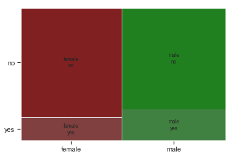

```python
mosaic(Dataframe, ['sex','smoker'])
plt.show()
```

Q4d. Is the distribution of bmi across women with no children, one child and two children, the same?

First of all we will create three subset of data based on number of children (0,1,2). Then compare the statistical points graphically and also state the hypothesis that all three sets have same statistical points (mainly mean). Also we will see through plotting how the datapoints are laid out.

```python
DF_Mom_0C =Dataframe[(Dataframe['children'] == 0) & (Dataframe['sex'] == 'female')]
DF_Mom_1C =Dataframe[(Dataframe['children'] == 1) & (Dataframe['sex'] == 'female')]
DF_Mom_2C =Dataframe[(Dataframe['children'] == 2) & (Dataframe['sex'] == 'female')]
```

```python
#calculating means for each dataset
print(DF_Mom_0C["bmi"].mean())
print(DF_Mom_1C["bmi"].mean())
print(DF_Mom_2C["bmi"].mean())
```

```
30.361522491349486
30.05265822784811
30.64978991596637
```

```python
DF_Mean_BMI = pd.DataFrame()

df0 = pd.DataFrame(index=[0],data={'Child' : '0', 'Mean_BMI' : DF_Mom_0C["bmi"].mean()})
df1 = pd.DataFrame(index=[1],data={'Child' : '1', 'Mean_BMI' : DF_Mom_1C["bmi"].mean()})
df2 = pd.DataFrame(index=[2],data={'Child' : '2', 'Mean_BMI' : DF_Mom_2C["bmi"].mean()})

DF_Mean_BMI = DF_Mean_BMI.append(df0)
DF_Mean_BMI = DF_Mean_BMI.append(df1)
DF_Mean_BMI = DF_Mean_BMI.append(df2)

DF_Mean_BMI
```

|  | Child | Mean_BMI |
| --- | --- | --- |
| 0 | 0 | 30.361522 |
| 1 | 1 | 30.052658 |
| 2 | 2 | 30.649790 |

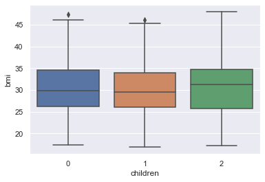

```python
sns.boxplot(x = "children", y = "bmi", data = Dataframe[(Dataframe['children'] <3) & (Dataframe['sex'] == 'female')])
plt.show()
```

Defining the hypothesis as H0-> Mean1 = Mean2 = Mean3 || Ha-> atleast one of the means differ from others. Assuming the alpha =0.05

```python
mod = ols('children ~ bmi', data = Dataframe[(Dataframe['children'] <3) & (Dataframe['sex'] == 'female')]).fit()
aov_table = sm.stats.anova_lm(mod, typ=2)
print(aov_table)
```

```
              sum_sq     df         F   PR(>F)
bmi         0.043290    1.0  0.068411  0.79376
Residual  356.896639  564.0       NaN      NaN
```